# Module 4 - Problem #3: What Is the Relationship between Housing Characteristics and Complaints?

## DataSets

1. **311 Compliant Dataset**
   1. All 311 Service Requests from 2010 to present
   2. 311 serves the public and handles all requests for government and non-emergency services, connecting residents, business owners, and visitors with the information and people who can help them best
   3. NYC311 can provide you access to non-emergency City services and information about City government programs.
      1. NYC311 can help with a broad range of services, including things like homeless person assistance, pothole repair, or help understanding a property tax bill
2. **PLUTO (Primary Land Use Tax Lot Output)**
   1. Contains 3 basic types of data
      1. Tax Lot Characteristics
      2. Building Characteristics
      3. Geographic/Political/Administrative Districts

## Problem Statement

**Does the Complaint Type that you identified in response to question 1 have an obvious relationship with any particular characteristic or characteristics of the houses or buildings?**

1. In this exercise, use the 311 dataset.
2. You also need to read back the PLUTO dataset from Cloud Object Store that you saved previously in the course.
   1. Use the PLUTO dataset for the borough that you already identified to focus on the last exercise.
   2. Ensure that you use only a limited number of fields from the dataset so that you are not consuming too much memory during your analysis.
   3. The recommended fields are Address, BldgArea, BldgDepth, BuiltFAR, CommFAR, FacilFAR, Lot, LotArea, LotDepth, NumBldgs, NumFloors, OfficeArea, ResArea, ResidFAR, RetailArea, YearBuilt, YearAlter1, ZipCode, YCoord, and XCoord.

**Idiosyncrasies regarding PLUTO**

1. The PLUTO data contain one record per tax lot, except for condominiums
   1. Instead of individual records for each condominium unit tax lot, PLUTO contains one record per condomium complex
2. Related to Borough and Community District Geography
   1. Located in one Borough, but are serviced by another borough

| City | Serviced by which Borough? | Legally Located in which Borough? | In which Borough Tax Lot? |
| --- | --- | --- | --- |
| Marble Hill | Bronx | Manhattan | Manhattan |
| Rikers Island | Queens | Bronx | Bronx |

# Setup

## 0. Library

```python
import numpy as np

import matplotlib.pyplot as plt
%matplotlib inline

def display_n(df,n):
    with pd.option_context('display.max_rows',n*2):
        display(df)
```

## 1. Load Complaint Data From CSV File

```python
df_complaint = pd.read_csv(body)
```

## 2. Clean Complaint Dataset

1. Remove the first dummy column
2. Cast the date fields to data type of DateTime[ns]
3. Replace the missing zip code values to 0 and cast the field as int
4. Fix the column names (strip whitespaces, replace space with "_", and lowercase them
5. Uppercase cell values as upper to standardize
6. Replace "HEATING" to "HEAT/HOT WATER"

```python
##### Let's clean up the dataset
# drop the first dummy column
df_complaint.drop(columns=['Unnamed: 0'], inplace=True)
print("Is Unname column in the dataframe?", ({'Unnamed: 0'}.issubset(df_complaint.columns)))

#cast the columns to correct type
# datetime
df_complaint['Created Date'] = pd.to_datetime(df_complaint['Created Date'], format="%m/%d/%Y %I:%M:%S %p", errors='coerce') # force the invalid to NaT
df_complaint['Closed Date'] = pd.to_datetime(df_complaint['Closed Date'], format="%m/%d/%Y %I:%M:%S %p", errors='coerce')   # force the invalid to NaT

#fix the zipcode - force the nan values to be 0
df_complaint['Incident Zip'].replace(np.nan, 0, inplace=True)             # let replace all of null with 0
df_complaint['Incident Zip'] = df_complaint['Incident Zip'].astype('int') # NaN are floats, so let cast the entire column as string

# fix the column names
df_complaint.columns = df_complaint.columns.str.strip()
df_complaint.columns = df_complaint.columns.str.replace(' ', '_')
df_complaint.columns = df_complaint.columns.str.lower()

#Strip leading and trailing whitespaces and upper all of the cell values - Borough was good before
fix_cols = ['complaint_type','location_type','incident_address','street_name','address_type','city','status','borough']
for i, name in enumerate(fix_cols):
    df_complaint[name]=df_complaint[name].str.upper().str.strip()


# Update the label related to hearting and hot/water
df_complaint['complaint_type'].replace('HEATING', 'HEAT/HOT WATER', inplace=True)

print("Shape of dataframe 311 = ", df_complaint.shape, "\n")
display_n(df_complaint,2)
```

```
Is Unname column in the dataframe? False
Shape of dataframe 311 =  (6019843, 15)
```

|  | unique_key | created_date | closed_date | complaint_type | location_type | incident_zip | incident_address | street_name | address_type | city | status | resolution_description | borough | latitude | longitude |
| --- | --- | --- | --- | --- | --- | --- | --- | --- | --- | --- | --- | --- | --- | --- | --- |
| 0 | 45531130 | 2020-02-02 06:09:17 | NaT | HEAT/HOT WATER | RESIDENTIAL BUILDING | 10019 | 426 WEST 52 STREET | WEST 52 STREET | ADDRESS | NEW YORK | OPEN | The following complaint conditions are still o... | MANHATTAN | 40.765132 | -73.988993 |
| 1 | 45529784 | 2020-02-02 14:15:24 | NaT | UNSANITARY CONDITION | RESIDENTIAL BUILDING | 11204 | 1751 67 STREET | 67 STREET | ADDRESS | BROOKLYN | OPEN | The following complaint conditions are still o... | BROOKLYN | 40.618484 | -73.992673 |
| ... | ... | ... | ... | ... | ... | ... | ... | ... | ... | ... | ... | ... | ... | ... | ... |
| 6019841 | 44063726 | 2019-10-15 14:07:34 | 2019-10-16 19:10:19 | HEAT/HOT WATER | RESIDENTIAL BUILDING | 10467 | 66 WEST GUN HILL ROAD | WEST GUN HILL ROAD | ADDRESS | BRONX | CLOSED | The Department of Housing Preservation and Dev... | BRONX | 40.883207 | -73.884279 |
| 6019842 | 44063737 | 2019-10-15 11:29:01 | 2019-10-15 21:19:45 | PAINT/PLASTER | RESIDENTIAL BUILDING | 10009 | 143 AVENUE D | AVENUE D | ADDRESS | NEW YORK | CLOSED | The Department of Housing Preservation and Dev... | MANHATTAN | 40.724749 | -73.975269 |

6019843 rows × 15 columns

## 3. Load the PLUTO Datasets

```python
# We only want some of the columns
selCols = ['Address', 'BldgArea', 'BldgDepth', 'BuiltFAR', 'CommFAR', 'FacilFAR', 'Lot',
           'LotArea', 'LotDepth', 'NumBldgs', 'NumFloors', 'OfficeArea', 'ResArea', 'ResidFAR', 'RetailArea',
           'YearBuilt', 'YearAlter1', 'ZipCode', 'YCoord', 'XCoord']
```

#### 3a. BK = Brooklyn

```python
df_BK = pd.read_csv(body,usecols=selCols)
display_n(df_BK,2)
```

|  | Lot | ZipCode | Address | LotArea | BldgArea | ResArea | OfficeArea | RetailArea | NumBldgs | NumFloors | LotDepth | BldgDepth | YearBuilt | YearAlter1 | BuiltFAR | ResidFAR | CommFAR | FacilFAR | XCoord | YCoord |
| --- | --- | --- | --- | --- | --- | --- | --- | --- | --- | --- | --- | --- | --- | --- | --- | --- | --- | --- | --- | --- |
| 0 | 1 | 11201.0 | JOHN STREET | 151930 | 0 | 0 | 0 | 0 | 0 | 0.0 | 337.42 | 0.0 | 0 | 0 | 0.00 | 0.0 | 2.0 | 0.0 | NaN | NaN |
| 1 | 50 | 11201.0 | 10 JAY STREET | 19682 | 163894 | 0 | 147505 | 16389 | 1 | 10.0 | 207.25 | 195.0 | 1920 | 1994 | 8.33 | 5.4 | 2.0 | 6.5 | 987838.0 | 195989.0 |
| ... | ... | ... | ... | ... | ... | ... | ... | ... | ... | ... | ... | ... | ... | ... | ... | ... | ... | ... | ... | ... |
| 277314 | 388 | 11229.0 | GARLAND COURT | 3570 | 0 | 0 | 0 | 0 | 0 | 0.0 | 52.50 | 0.0 | 0 | 0 | 0.00 | 0.6 | 0.5 | 1.0 | NaN | NaN |
| 277315 | 392 | 11229.0 | GARLAND COURT | 3209 | 0 | 0 | 0 | 0 | 0 | 0.0 | 46.50 | 0.0 | 0 | 0 | 0.00 | 0.6 | 0.5 | 1.0 | NaN | NaN |

277316 rows × 20 columns

#### 3b. BX = Bronx

```python
df_BX = pd.read_csv(body,usecols=selCols)
display_n(df_BX,2)
```

|  | Lot | ZipCode | Address | LotArea | BldgArea | ResArea | OfficeArea | RetailArea | NumBldgs | NumFloors | LotDepth | BldgDepth | YearBuilt | YearAlter1 | BuiltFAR | ResidFAR | CommFAR | FacilFAR | XCoord | YCoord |
| --- | --- | --- | --- | --- | --- | --- | --- | --- | --- | --- | --- | --- | --- | --- | --- | --- | --- | --- | --- | --- |
| 0 | 1 | 10454.0 | 122 BRUCKNER BOULEVARD | 15000 | 0 | 0 | 0 | 0 | 1 | 0.0 | 200.0 | 0.0 | 0 | 0 | 0.00 | 6.02 | 5.0 | 6.5 | 1005957.0 | 232162.0 |
| 1 | 4 | 10454.0 | 126 BRUCKNER BOULEVARD | 13770 | 752 | 0 | 272 | 0 | 2 | 1.0 | 100.0 | 16.0 | 1931 | 1994 | 0.05 | 6.02 | 5.0 | 6.5 | 1006076.0 | 232156.0 |
| ... | ... | ... | ... | ... | ... | ... | ... | ... | ... | ... | ... | ... | ... | ... | ... | ... | ... | ... | ... | ... |
| 89852 | 8900 | NaN | NaN | 0 | 0 | 0 | 0 | 0 | 0 | 0.0 | 0.0 | 0.0 | 0 | 0 | 0.00 | 0.00 | 0.0 | 0.0 | NaN | NaN |
| 89853 | 8900 | NaN | NaN | 0 | 0 | 0 | 0 | 0 | 0 | 0.0 | 0.0 | 0.0 | 0 | 0 | 0.00 | 0.00 | 0.0 | 0.0 | NaN | NaN |

89854 rows × 20 columns

#### 3c. MN = Manhattan

```python
df_MN = pd.read_csv(body,usecols=selCols)
display_n(df_MN,2)
```

|  | Lot | ZipCode | Address | LotArea | BldgArea | ResArea | OfficeArea | RetailArea | NumBldgs | NumFloors | LotDepth | BldgDepth | YearBuilt | YearAlter1 | BuiltFAR | ResidFAR | CommFAR | FacilFAR | XCoord | YCoord |
| --- | --- | --- | --- | --- | --- | --- | --- | --- | --- | --- | --- | --- | --- | --- | --- | --- | --- | --- | --- | --- |
| 0 | 10 | 10004.0 | 1 GOVERNORS ISLAND | 7736692 | 2725731 | 0 | 0 | 0 | 159 | 0.0 | 0.0 | 0.0 | 1900 | 0 | 0.35 | 0.60 | 0.0 | 1.0 | 979071.0 | 190225.0 |
| 1 | 101 | 10004.0 | 1 LIBERTY ISLAND | 541886 | 541886 | 0 | 0 | 0 | 11 | 0.0 | 1046.0 | 0.0 | 1900 | 0 | 1.00 | 0.60 | 0.0 | 1.0 | 971677.0 | 190636.0 |
| ... | ... | ... | ... | ... | ... | ... | ... | ... | ... | ... | ... | ... | ... | ... | ... | ... | ... | ... | ... | ... |
| 42964 | 1031 | 10034.0 | DYCKMAN STREET | 30525 | 0 | 0 | 0 | 0 | 0 | 0.0 | 947.5 | 0.0 | 0 | 0 | 0.00 | 3.44 | 0.0 | 6.5 | NaN | NaN |
| 42965 | 2000 | 10034.0 | 269 DYCKMAN STREET | 11320000 | 0 | 0 | 0 | 0 | 7 | 1.0 | 5000.0 | 0.0 | 1940 | 0 | 0.00 | 0.00 | 0.0 | 0.0 | 1004800.0 | 257521.0 |

42966 rows × 20 columns

#### 3d. QN = Queen

```python
df_QN = pd.read_csv(body,usecols=selCols)
display_n(df_QN,2)
```

|  | Lot | ZipCode | Address | LotArea | BldgArea | ResArea | OfficeArea | RetailArea | NumBldgs | NumFloors | LotDepth | BldgDepth | YearBuilt | YearAlter1 | BuiltFAR | ResidFAR | CommFAR | FacilFAR | XCoord | YCoord |
| --- | --- | --- | --- | --- | --- | --- | --- | --- | --- | --- | --- | --- | --- | --- | --- | --- | --- | --- | --- | --- |
| 0 | 1 | 11101.0 | 2 STREET | 1684828 | 0 | 0 | 0 | 0 | 0 | 0.0 | 268.00 | 0.0 | 0 | 0 | 0.00 | 10.0 | 0.0 | 10.0 | NaN | NaN |
| 1 | 3 | 11101.0 | 2 STREET | 21139 | 0 | 0 | 0 | 0 | 1 | 0.0 | 110.00 | 0.0 | 0 | 0 | 0.00 | 10.0 | 0.0 | 10.0 | 995513.0 | 209421.0 |
| ... | ... | ... | ... | ... | ... | ... | ... | ... | ... | ... | ... | ... | ... | ... | ... | ... | ... | ... | ... | ... |
| 324581 | 400 | 11697.0 | 217-02 BREEZY POINT BLVD | 12253428 | 1600000 | 1600000 | 0 | 0 | 1850 | 1.0 | 997.00 | 40.0 | 1938 | 0 | 0.13 | 0.9 | 0.0 | 2.0 | 1006277.0 | 142173.0 |
| 324582 | 500 | NaN | 422 ROCKAWAY POINT BLVD | 8276400 | 12252000 | 0 | 0 | 0 | 1 | 1.0 | 2099.92 | 0.0 | 1929 | 0 | 1.48 | 0.0 | 0.0 | 0.0 | NaN | NaN |

324583 rows × 20 columns

## 4. Look at Pluto and clean up if necessary

```python
#UNION the dataframes and reset the index
df_pluto = pd.concat([df_BK, df_BX, df_MN, df_QN], ignore_index=True)
```

```python
df_pluto.info(verbose=True, null_counts=True) # output statistics
```

```
<class 'pandas.core.frame.DataFrame'>
RangeIndex: 734719 entries, 0 to 734718
Data columns (total 20 columns):
 #   Column      Non-Null Count   Dtype
---  ------      --------------   -----
 0   Lot         734719 non-null  int64
 1   ZipCode     732341 non-null  float64
 2   Address     734244 non-null  object
 3   LotArea     734719 non-null  int64
 4   BldgArea    734719 non-null  int64
 5   ResArea     734719 non-null  int64
 6   OfficeArea  734719 non-null  int64
 7   RetailArea  734719 non-null  int64
 8   NumBldgs    734719 non-null  int64
 9   NumFloors   734719 non-null  float64
 10  LotDepth    734719 non-null  float64
 11  BldgDepth   734719 non-null  float64
 12  YearBuilt   734719 non-null  int64
 13  YearAlter1  734719 non-null  int64
 14  BuiltFAR    734719 non-null  float64
 15  ResidFAR    734719 non-null  float64
 16  CommFAR     734719 non-null  float64
 17  FacilFAR    734719 non-null  float64
 18  XCoord      718883 non-null  float64
 19  YCoord      718883 non-null  float64
dtypes: float64(10), int64(9), object(1)
memory usage: 112.1+ MB
```

#### Another way to check if there are nulls in the dataset

```python
# Analyze the number of fields with missing values
df_missing = df_pluto.isnull().sum().to_frame().reset_index()                                     # Count number of Null values for all columns in the dataframe
df_missing.rename(columns={'index':'FieldName', 0 : 'NullCount'}, inplace=True)                   # rename the dataframe
print("Number of Fields with Missing values: ", df_missing[df_missing['NullCount']!=0].shape[0])  # Report number of fields that have null values > 0
df_missing[df_missing['NullCount']!=0]                                                            # Only display field names with missing values
```

```
Number of Fields with Missing values:  4
```

|  | FieldName | NullCount |
| --- | --- | --- |
| 1 | ZipCode | 2378 |
| 2 | Address | 475 |
| 18 | XCoord | 15836 |
| 19 | YCoord | 15836 |

# Question #1:

**Can you determine the age of the building from the PLUTO dataset?**

```python
from datetime import date

today = date.today()                                                                # today's date
yr = int(today.strftime("%Y"))                                                      # Get Year Datepart of Today's date
print("Today's year =", yr, "; ", type(yr))

df_pluto['age'] = df_pluto['YearBuilt'].apply(lambda x: 0 if x <= 0 else (yr - x))  # if yearbuilt <=0, then age=0, else perform the calculation of Yr minus YearBuilt

display_n(df_pluto[['YearBuilt', 'age']], 5)                                        # show some examples
```

```
Today's year = 2020 ;  <class 'int'>
```

|  | YearBuilt | age |
| --- | --- | --- |
| 0 | 0 | 0 |
| 1 | 1920 | 100 |
| 2 | 0 | 0 |
| 3 | 0 | 0 |
| 4 | 0 | 0 |
| ... | ... | ... |
| 734714 | 0 | 0 |
| 734715 | 0 | 0 |
| 734716 | 0 | 0 |
| 734717 | 1938 | 82 |
| 734718 | 1929 | 91 |

734719 rows × 2 columns

# Question #3: This should be answered before Question 2 before doing the analysis

**The cardinality of the data in PLUTO dataset is at the same level as the Complaint dataset?**

```python
# Install the brokenaxes package

!pip install brokenaxes
```

### Q3 - Part 1 - Let's look at number of unique values for each column in both of our datasets

We should visit this link by [clicking here](https://subscription.packtpub.com/book/data/9781789806311/1/ch01lvl1sec05/determining-cardinality-in-categorical-variables)

```python
df_pluto_unique = df_pluto.nunique().to_frame().reset_index()                             # For each column, give me the number of unique values, excluding nulls
df_pluto_unique.rename(columns={'index':'FieldName', 0 : 'NumUniqValues'}, inplace=True)  # rename the columns of the dataframe

print('Mean Unique Values of Pluto: ', df_pluto_unique["NumUniqValues"].mean())           # report back the mean number of unique values across all columns

df_pluto_unique.sort_values(by=['NumUniqValues'], inplace=True, ascending=False)          # sort
df_pluto_unique.head()
# df_pluto_unique.plot.bar(x='FieldName', y='NumUniqValues', rot=90, figsize=(12, 6))
```

```
Mean Unique Values of Pluto:  50229.95238095238
```

|  | FieldName | NumUniqValues |
| --- | --- | --- |
| 2 | Address | 714148 |
| 19 | YCoord | 116439 |
| 18 | XCoord | 90717 |
| 4 | BldgArea | 36598 |
| 5 | ResArea | 27682 |

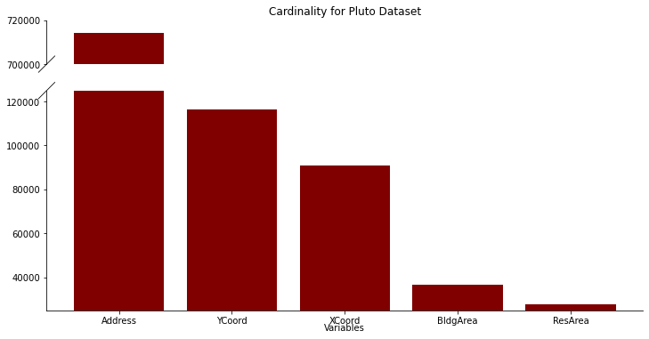

```python
from brokenaxes import brokenaxes

x = df_pluto_unique['FieldName'].head(5)
y = df_pluto_unique['NumUniqValues'].head(5)

#generate the plot
fig = plt.figure(figsize=(12,6))
baxes = brokenaxes(ylims=((25000,125000),(700000,720000)), hspace=.20)

baxes.bar(x, y, color ='maroon')
baxes.set_xlabel('Variables')
baxes.set_title('Cardinality for Pluto Dataset')
```

### Q3 - Part 2 - Let's focus on Address Column

We're going to Compare the ratio between Cardinality (Unique) to Row Count (excluding nulls)

```python
pluto_metrics = df_pluto['Address'].describe()                       # FROM PLUTO DATASET, get stats on Address column
pluto_metrics
```

```
count              734244
unique             714148
top       ATLANTIC AVENUE
freq                   89
Name: Address, dtype: object
```

```python
complaint_metrics = df_complaint['incident_address'].describe()    # FROM PLUTO DATASET, get stats on Address column
complaint_metrics
```

```
count             5967018
unique             182600
top       34 ARDEN STREET
freq                14298
Name: incident_address, dtype: object
```

```python
ct_ratio = complaint_metrics['unique'] / complaint_metrics['count']
pluto_ratio = pluto_metrics['unique'] / complaint_metrics['count']

if (ct_ratio > pluto_ratio):
    print("Complaint has a higher cardinality than Pluto")
elif (ct_ratio == pluto_ratio):
    print("Complaint has the same cardinality as Pluto")
else:
    print("Complaint has a lower cardinality than Pluto")

print("Complaint Ratio: %.4f" % ct_ratio)
print("Pluto Ratio: %.4f" % pluto_ratio)
```

```
Complaint has a lower cardinality than Pluto
Complaint Ratio: 0.0306
Pluto Ratio: 0.1197
```

### Q3 - Part 3 - Remove the duplicates in Pluto Dataset

The above ratios indicate that there are some duplication at some level(s) in both datasets. It's expected for the Complaint dataset, but not for Pluto dataset.

```python
duplicateRowsDF = df_pluto[df_pluto.duplicated()]
duplicateRowsDF.sort_values(list(duplicateRowsDF.columns)).head()
```

|  | Lot | ZipCode | Address | LotArea | BldgArea | ResArea | OfficeArea | RetailArea | NumBldgs | NumFloors | ... | BldgDepth | YearBuilt | YearAlter1 | BuiltFAR | ResidFAR | CommFAR | FacilFAR | XCoord | YCoord | age |
| --- | --- | --- | --- | --- | --- | --- | --- | --- | --- | --- | --- | --- | --- | --- | --- | --- | --- | --- | --- | --- | --- |
| 581690 | 1 | 11363.0 | 230 STREET | 60000 | 0 | 0 | 0 | 0 | 0 | 0.0 | ... | 0.0 | 0 | 0 | 0.0 | 0.00 | 0.0 | 0.0 | NaN | NaN | 0 |
| 116100 | 1 | NaN | FLATLANDS AVENUE | 93000 | 0 | 0 | 0 | 0 | 0 | 0.0 | ... | 0.0 | 0 | 0 | 0.0 | 2.43 | 0.0 | 4.8 | NaN | NaN | 0 |
| 116101 | 1 | NaN | FLATLANDS AVENUE | 93000 | 0 | 0 | 0 | 0 | 0 | 0.0 | ... | 0.0 | 0 | 0 | 0.0 | 2.43 | 0.0 | 4.8 | NaN | NaN | 0 |
| 19486 | 1 | NaN | NaN | 0 | 0 | 0 | 0 | 0 | 0 | 0.0 | ... | 0.0 | 0 | 0 | 0.0 | 0.00 | 0.0 | 0.0 | NaN | NaN | 0 |
| 314916 | 1 | NaN | NaN | 0 | 0 | 0 | 0 | 0 | 0 | 0.0 | ... | 0.0 | 0 | 0 | 0.0 | 0.00 | 0.0 | 0.0 | NaN | NaN | 0 |

5 rows × 21 columns

```python
print("Before (based on all cols) - # of Duplicate Rows: ", df_pluto.duplicated().sum())                    # Report - Before
df_pluto.drop_duplicates(inplace=True)                                                                      # drop all duplicates based all columns
print("After (based on all cols) - # of Duplicate Rows: ", df_pluto.duplicated().sum(), "\n")               # Report - After

print("Before (based on Address)  - # of Duplicate Rows: ", df_pluto.duplicated(subset=['Address']).sum())   # Report
df_pluto.drop_duplicates(subset=['Address'],inplace=True)                                                    # drop all duplicates based Address only
print("After (based on Address)  - # of Duplicate Rows: ", df_pluto.duplicated(subset=['Address']).sum())    # Report
```

```
Before (based on all cols) - # of Duplicate Rows:  208
After (based on all cols) - # of Duplicate Rows:  0

Before (based on Address)  - # of Duplicate Rows:  20362
After (based on Address)  - # of Duplicate Rows:  0
```

After removing duplicates based on all records and then by address only, let's look at the missing

```python
df_missing = df_pluto.isnull().sum().to_frame().reset_index()                                       # Count number of Null values for all columns in the dataframe
df_missing.rename(columns={'index':'FieldName', 0 : 'NullCount'}, inplace=True)                     # rename the columns in dataframe
print("Number of Fields with Missing values: ", df_missing[df_missing['NullCount']!=0].shape[0])    # Report number of fields that have null values > 0
df_missing[df_missing['NullCount']!=0]                                                              # Only display field names with missing values
```

```
Number of Fields with Missing values:  4
```

|  | FieldName | NullCount |
| --- | --- | --- |
| 1 | ZipCode | 353 |
| 2 | Address | 1 |
| 18 | XCoord | 4652 |
| 19 | YCoord | 4652 |

```python
df_pluto.dropna(how='all', inplace=True)                                        # Drop any row when ALL columns are NaN
df_pluto.dropna(subset=['Address','ZipCode','XCoord','YCoord'], inplace=True)   # Drop any row with a blank address, zipcode, xcord, or ycord

df_missing = df_pluto.isnull().sum().to_frame().reset_index()                   # Count number of Null values for all columns in the dataframe
df_missing.rename(columns={'index':'FieldName', 0 : 'NullCount'}, inplace=True) # rename the dataframe
print("Number of Fields with Missing values: ",
      df_missing[df_missing['NullCount']!=0].shape[0])                          # Report number of fields that have null values > 0
df_missing[df_missing['NullCount']!=0]                                          # Only display field names with missing values
```

```
Number of Fields with Missing values:  0
```

|  | FieldName | NullCount |
| --- | --- | --- |

# More pre-processing - Add another column to Pluto table

1. Okay, we cleaned up our Pluto Dataset, which is our feature set. We want to see if Building characters are related to the number of Heating complaints reported since 2010
2. We'll join the tables based on Address

```python
filter1 = df_complaint['complaint_type'].isin(['HEAT/HOT WATER', 'HEATING'])                 # Creating filter of bool series from isin()
df_heat = df_complaint[filter1]                                                              # Filter for Heating related issues

df_address_count = df_heat.groupby(['incident_address']).size().reset_index(name='count')    # by address, count the number of heating issues
display_n(df_address_count,2)                                                                # display some rows
```

|  | incident_address | count |
| --- | --- | --- |
| 0 | 1 1 AVENUE | 2 |
| 1 | 1 12 STREET | 1 |
| ... | ... | ... |
| 136947 | EAST 207 STREET | 1 |
| 136948 | UNKNOWN | 1 |

136949 rows × 2 columns

```python
df_pluto['heat_complaint_count'] = df_pluto['Address'].map(df_heat['incident_address'].value_counts())      # Count occurences for each address in df_heat['incident_address']
                                                                                                            # and then use Series.map to apply those counts to corresponding values in df_pluto['Address']

df_pluto['heat_complaint_count'].replace(np.nan, 0, inplace=True)                                           # let replace all of null with 0
```

```python
df_pluto[df_pluto['heat_complaint_count']!=0].head()
```

|  | Lot | ZipCode | Address | LotArea | BldgArea | ResArea | OfficeArea | RetailArea | NumBldgs | NumFloors | ... | YearBuilt | YearAlter1 | BuiltFAR | ResidFAR | CommFAR | FacilFAR | XCoord | YCoord | age | heat_complaint_count |
| --- | --- | --- | --- | --- | --- | --- | --- | --- | --- | --- | --- | --- | --- | --- | --- | --- | --- | --- | --- | --- | --- |
| 25 | 14 | 11201.0 | 64 JOHN STREET | 21150 | 33575 | 0 | 0 | 0 | 4 | 2.0 | ... | 1900 | 0 | 1.59 | 4.00 | 2.0 | 4.0 | 988271.0 | 195827.0 | 120 | 1.0 |
| 48 | 7502 | 11201.0 | 133 WATER STREET | 10010 | 57668 | 54917 | 0 | 0 | 1 | 12.0 | ... | 2006 | 0 | 5.76 | 6.02 | 6.0 | 6.5 | 987282.0 | 195535.0 | 14 | 5.0 |
| 70 | 7502 | 11201.0 | 50 BRIDGE STREET | 41238 | 171382 | 70140 | 0 | 0 | 2 | 6.0 | ... | 1904 | 2004 | 4.16 | 4.00 | 2.0 | 4.0 | 988290.0 | 195540.0 | 116 | 1.0 |
| 78 | 29 | 11201.0 | 56 GOLD STREET | 19800 | 19800 | 0 | 0 | 0 | 1 | 1.0 | ... | 1950 | 1987 | 1.00 | 0.00 | 2.0 | 4.8 | 988942.0 | 195479.0 | 70 | 1.0 |
| 82 | 7501 | 11201.0 | 37 BRIDGE STREET | 12500 | 59244 | 51952 | 0 | 6631 | 2 | 7.0 | ... | 1916 | 0 | 4.74 | 4.00 | 2.0 | 4.0 | 988588.0 | 195564.0 | 104 | 1.0 |

5 rows × 22 columns

filter2 = df_address_count['incident_address'].isin(['64 JOHN STREET', '133 WATER STREET']) # Creating filter of bool series from isin() df_address_count[filter2] # Just to double check

```python
df_pluto['heat_flag'] = [1 if x >= 1 else 0 for x in df_pluto['heat_complaint_count']]       # create flag 1 if complaint >=1 , else 0
df_pluto[df_pluto['heat_flag']==1]                                                           # display some dataframe rows
```

|  | Lot | ZipCode | Address | LotArea | BldgArea | ResArea | OfficeArea | RetailArea | NumBldgs | NumFloors | ... | YearAlter1 | BuiltFAR | ResidFAR | CommFAR | FacilFAR | XCoord | YCoord | age | heat_complaint_count | heat_flag |
| --- | --- | --- | --- | --- | --- | --- | --- | --- | --- | --- | --- | --- | --- | --- | --- | --- | --- | --- | --- | --- | --- |
| 25 | 14 | 11201.0 | 64 JOHN STREET | 21150 | 33575 | 0 | 0 | 0 | 4 | 2.00 | ... | 0 | 1.59 | 4.00 | 2.0 | 4.0 | 988271.0 | 195827.0 | 120 | 1.0 | 1 |
| 48 | 7502 | 11201.0 | 133 WATER STREET | 10010 | 57668 | 54917 | 0 | 0 | 1 | 12.00 | ... | 0 | 5.76 | 6.02 | 6.0 | 6.5 | 987282.0 | 195535.0 | 14 | 5.0 | 1 |
| 70 | 7502 | 11201.0 | 50 BRIDGE STREET | 41238 | 171382 | 70140 | 0 | 0 | 2 | 6.00 | ... | 2004 | 4.16 | 4.00 | 2.0 | 4.0 | 988290.0 | 195540.0 | 116 | 1.0 | 1 |
| 78 | 29 | 11201.0 | 56 GOLD STREET | 19800 | 19800 | 0 | 0 | 0 | 1 | 1.00 | ... | 1987 | 1.00 | 0.00 | 2.0 | 4.8 | 988942.0 | 195479.0 | 70 | 1.0 | 1 |
| 82 | 7501 | 11201.0 | 37 BRIDGE STREET | 12500 | 59244 | 51952 | 0 | 6631 | 2 | 7.00 | ... | 0 | 4.74 | 4.00 | 2.0 | 4.0 | 988588.0 | 195564.0 | 104 | 1.0 | 1 |
| ... | ... | ... | ... | ... | ... | ... | ... | ... | ... | ... | ... | ... | ... | ... | ... | ... | ... | ... | ... | ... | ... |
| 733907 | 61 | 11694.0 | 1-42 BEACH 138 STREET | 6000 | 2174 | 2174 | 0 | 0 | 2 | 2.00 | ... | 0 | 0.36 | 0.50 | 0.0 | 1.0 | 1024836.0 | 147470.0 | 80 | 2.0 | 1 |
| 734038 | 1 | 11694.0 | 147-02 NEWPORT AVENUE | 40600 | 12000 | 0 | 0 | 0 | 2 | 2.00 | ... | 0 | 0.30 | 0.50 | 0.0 | 1.0 | 1021783.0 | 148166.0 | 63 | 1.0 | 1 |
| 734123 | 37 | 11694.0 | 143-04 NEWPORT AVENUE | 4000 | 1283 | 1283 | 0 | 0 | 1 | 1.00 | ... | 2017 | 0.32 | 0.50 | 0.0 | 1.0 | 1022896.0 | 148469.0 | 3 | 1.0 | 1 |
| 734206 | 29 | 11694.0 | 243 BEACH 141 STREET | 4000 | 1733 | 1733 | 0 | 0 | 2 | 1.67 | ... | 0 | 0.43 | 0.50 | 0.0 | 1.0 | 1023553.0 | 148145.0 | 65 | 1.0 | 1 |
| 734280 | 38 | 11694.0 | 144-16 NEPONSIT AVENUE | 6000 | 2034 | 1356 | 0 | 0 | 1 | 1.00 | ... | 0 | 0.34 | 0.50 | 0.0 | 1.0 | 1022792.0 | 147691.0 | 75 | 1.0 | 1 |

101959 rows × 23 columns

#### At this point, I want to bring the borough into the pluto dataset

```python
dict_address = pd.Series(df_complaint.borough.values,index=df_complaint.incident_address).to_dict()
df_pluto["borough"] = df_pluto["Address"].map(dict_address)
df_pluto['borough'].value_counts(ascending=False, dropna=False)
```

```
NaN              575542
BROOKLYN          49868
QUEENS            35537
BRONX             21419
MANHATTAN         16640
UNSPECIFIED       10330
STATEN ISLAND       157
Name: borough, dtype: int64
```

# Finally, we are ready

Thoughts before we start:

- Let's see if there are connections between building features and heat complaint flag (or heat complaint count)
- Delete objects

```python
del df_complaint
del df_BK
del df_BX
del df_MN
del df_QN

del baxes

del df_missing
del df_pluto_unique

del pluto_metrics
del complaint_metrics

del filter1
# del filter2

del duplicateRowsDF
del dict_address
del df_address_count

del ct_ratio
del pluto_ratio
```

# Question #2:

**Which of the following methodologies can you use to identify whether any relationship exist between the building characteristics and the number of complaints?** 1. Pearson Correlation 2. Feature Importance from Random Forest 3. Feature Importance Function from XGBoost Algorithm

## 2a. Pearson Correlation

### Let's get a visual representation first

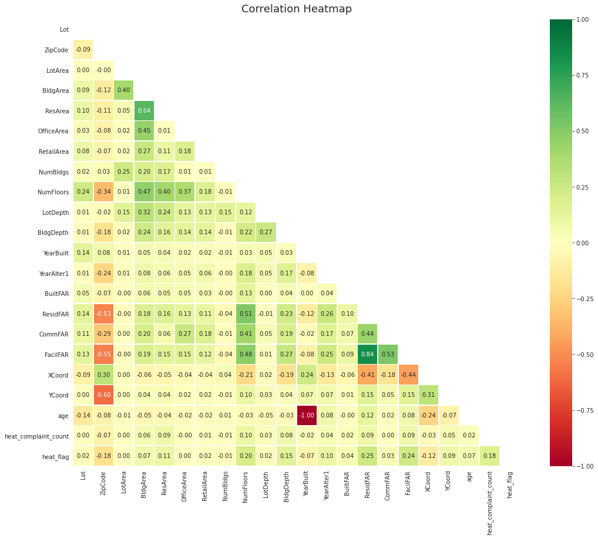

```python
import seaborn as sns

corr = df_pluto.query('YearBuilt != 0').corr(method="pearson")                # using Pearson correlation, but exclude rows where YearBuilt=0 (as-in the data was not provided)

mask = np.triu(np.ones_like(corr, dtype=bool))                                # Generate a mask for the upper triangle
                                                                              # If passed, data will not be shown in cells where mask is True.
                                                                              # Cells with missing values are automatically masked

with sns.axes_style("white"):                                                 # Draw the heatmap with the mask
    f, ax = plt.subplots(figsize=(18, 14))                                    # figure size
    ax = sns.heatmap(corr, mask=mask, cmap=plt.cm.RdYlGn, vmin=-1, vmax=1,    # Set color map and range for corr
                     annot = True, fmt=".2f",                                 # Turn on Annotation and Adjust format to 2 decimal places
                     linewidths=.5, square=True)
    ax.set_title('Correlation Heatmap', fontdict={'fontsize':18}, pad=12)     # Set the title of the graph
```

```python
from scipy import stats
stats.describe(abs(corr.values[np.triu_indices_from(corr.values,1)])) # returns the indices for the upper triangle of the array,
                                                                      # then perform absolute on values, and finally give me the stats
                                                                      # mostly interested in the average correlation value
```

```
DescribeResult(nobs=231, minmax=(5.3418562774381034e-05, 1.0000000000000024), mean=0.12190567488922578, variance=0.021922256716104586, skewness=2.4414455692801686, kurtosis=8.005754801362672)
```

### Let's grab a list of variables that are decently correlated with either heat complaint count or heat flag

1. It looks like `ZipCode`, `NumFloors`, `BldgDepth`, `ResidFar`, and `FacilFar` made the threshold when comparing with `heat_flag` indicator
   1. Logistic Regression would be better suited since `heat_flag` is categorical variable
2. Interestingly, `age` didn't show up.
   1. It may have popped up if we focus one bourgh

```python
heat_list = ['heat_complaint_count','heat_flag']    # Target feature column list
indices = np.where(abs(corr) >= 0.12)               # Set Threshold of any Pearson correlation of 0.12

# Create a list of sets with index name, column name, and Pearson correlation
threshold = [(corr.index[x], corr.columns[y], corr.iloc[x][y]) for x, y in zip(*indices)
                                                               if x != y and x < y  and   # avoid top half of the corr dataframe
                                                               (corr.index[x] in heat_list or corr.columns[y] in heat_list) ]
threshold
```

```
[('ZipCode', 'heat_flag', -0.18413086057887654),
 ('NumFloors', 'heat_flag', 0.20482833262212957),
 ('BldgDepth', 'heat_flag', 0.1508100164267275),
 ('ResidFAR', 'heat_flag', 0.24739053851519274),
 ('FacilFAR', 'heat_flag', 0.2370358328295909),
 ('heat_complaint_count', 'heat_flag', 0.18438670630660728)]
```

### Weak Linear Relationship between building age and number of complaints

Didn't make the Top 5 as shown above when looking at the below list

```python
corr_target = abs(corr["heat_complaint_count"])          # Correlation with Heat Complaint Count Only
corr_target.sort_values(ascending=False, inplace=True)   # Sort the Series
corr_target.head(7)                                      # Output the Top 7 categories
```

```
heat_complaint_count    1.000000
heat_flag               0.184387
NumFloors               0.102112
ResArea                 0.092768
ResidFAR                0.087793
FacilFAR                0.085851
BldgDepth               0.078674
Name: heat_complaint_count, dtype: float64
```

### Graphically, let's see if "Building Age" as a predictor variable of "Heat Complaint Count" to confirm Weak Relationship

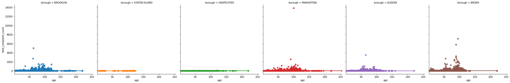

```python
import seaborn as sns

# Graph by Borough, exclude when Borough is null
g = sns.lmplot(x="age", y="heat_complaint_count", hue="borough", col="borough",
               data=df_pluto.query('YearBuilt != 0 & borough == borough'))
```

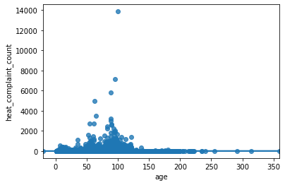

```python
# across all boroughs, including the nulls
g2 = sns.regplot(x="age", y="heat_complaint_count", data=df_pluto.query('YearBuilt != 0'))
```

```python
del corr
del mask

del corr_target
del indices
del threshold

del g
del g2
```

## 2b. Feature Importance from Random Forest

### Strategy

1. Use the Random Forest Classifer to predict Target 1 (get a heat complaint Y/N) - Classificaton Model
2. Use the Random Forest Regressor to predict Target 2 (number of complaints) - Regression Model

### Pre-processing

Using **Pluto** that includes 2 possible targets, declare the following variables:

- **X** as the **Feature Matrix** (Pluto Data)
- **y** as the **response vector** (Target = # of complaints)

Just get a dataframe **excluding** records that don't have year provided and removing outliers with complaints >= 4000

```python
df_pluto = df_pluto.query('YearBuilt != 0 & heat_complaint_count <  4000')
print(df_pluto.shape)
df_pluto.reset_index(inplace=True, drop=True)
```

```
(695195, 24)
```

#### Get Feature and Target data sets. Next, we split the dataset into Training and Testing

Phew - we don't need `preprocessing.LabelEncoder()` because we don't have categorical variables in our feature set.

```python
X = df_pluto.drop(['Address', 'XCoord', 'YCoord', 'borough','heat_complaint_count','heat_flag'],1) # Columns for Feature Set
y = df_pluto[['heat_flag','heat_complaint_count']]                                                 # Columns for Target Set

feature_labels = list(X.columns)                                                          # List of feature labels for model
target_labels = list(y.columns)                                                           # List of target labels for model

print('Feature Labels: ', feature_labels)                                                 # Print Feature labels
print('Target Labels: ', target_labels)                                                   # Print target labels

from sklearn.model_selection import train_test_split
X_train, X_test, y_train, y_test = train_test_split(X, y, test_size=0.3, random_state=3)  # Split the data into 30% test and 70% training

print('Train set:', X_train.shape,  y_train.shape)                                        # Print the shape of df from Trainset
print('Test set: ', X_test.shape ,  y_test.shape )                                        # Print the shape of df from Testset
```

```
Feature Labels:  ['Lot', 'ZipCode', 'LotArea', 'BldgArea', 'ResArea', 'OfficeArea', 'RetailArea', 'NumBldgs', 'NumFloors', 'LotDepth', 'BldgDepth', 'YearBuilt', 'YearAlter1', 'BuiltFAR', 'ResidFAR', 'CommFAR', 'FacilFAR', 'age']
Target Labels:  ['heat_flag', 'heat_complaint_count']
Train set: (486636, 18) (486636, 2)
Test set:  (208559, 18) (208559, 2)
```

**Create a pipeline that Standardizes the data, then train the randomforest classifier using feature X and and target in y (specifically Heat_Flag)**

```python
from sklearn.preprocessing import StandardScaler
from sklearn.ensemble import RandomForestClassifier
from sklearn.pipeline import Pipeline

# creating a list of tuples including the name of the model or estimator and its corresponding constructor
Input=[('scale',StandardScaler()),
       ('clf', RandomForestClassifier(random_state=0, n_jobs=2))   # We only have 2 labels 1 or 0
      ]

pipe=Pipeline(steps=Input)                                         # We input the list as an argument to the pipeline constructor
pipe.fit(X_train,y_train['heat_flag'])                             # We can normalize Target 1 in first column, perform a transform and Train the model simultaneously.

clf = pipe.steps[1][1]                                             # Retrieve the model from Pipeline object; Use this object reference later on

importances = clf.feature_importances_                             # Let's begin by gettig the importance values

# Print the name and importance value of each feature
# for feature in zip(feature_labels, clf.feature_importances_):
#     print(feature)
```

```python
list_of_tuples = list(zip(feature_labels, clf.feature_importances_))                # step 1: get the list of tuples from two lists and merge them by using zip().

df1 = pd.DataFrame(list_of_tuples, columns = ['feature_labels', 'importance'])      # Converting lists of tuples into pandas Dataframe.

df1.sort_values(by=['importance'], ascending=False, inplace=True)                   # Sort dataframe
df1.reset_index(inplace=True, drop=True)                                            # Reset dataframe index
```

```
Mean: 0.0556
```

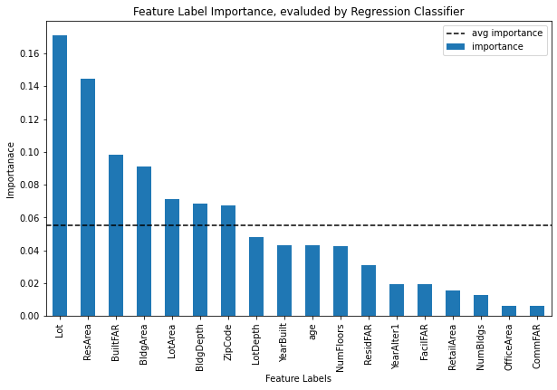

```python
mean_importance = df1['importance'].mean()                                          # Get Mean Importance Value
print('Mean: %.4f' % mean_importance)                                               # print Importance Mean value
df1.plot(kind='bar', figsize=(10, 6))                                               # step 2: plot data the dataframe

x_values = list(range(len(df1['feature_labels'].values)))                           # list of x locations for plotting [0,1,2,3,...,15,16,17]
plt.xticks(x_values, list(df1['feature_labels'].values))                            # Tick labels for x axis

plt.xlabel('Feature Labels')                                                        # add to x-label to the plot
plt.ylabel('Importanace')                                                           # add y-label to the plot
plt.title('Feature Label Importance, evaluded by Regression Classifier')            # add title to the plot
plt.axhline(mean_importance,linestyle='--',color='black', label='avg importance')   # Plot horizontal mean line

plt.legend()
plt.show()
```

### Evaluation of Classifier, before we select the features with above average importance

Predit with Test Set

```python
yhat = pipe.predict(X_test)
```

Evaluate based on Out-of-Sample (aka Test Set) Looking at all columns

```python
# With Libraries
from sklearn.metrics import accuracy_score
print("Classifier's Accuracy: %.5f" % accuracy_score(y_test['heat_flag'], yhat))

from sklearn.metrics import jaccard_score
print("Jaccard_score : %.5f" % jaccard_score(y_test['heat_flag'], yhat, average='micro'))
```

```
Classifier's Accuracy: 0.86751
Jaccard_score : 0.76602
```

```python
#Perform Mannually

c=sum(y_test['heat_flag']==yhat) #shortcut - index wise calculate number of matching

print("Matches : ", c)
print("# of elements in test array : ", len(y_test['heat_flag']))
print("# of elements in predicted array : ",len(yhat))

print("")

pct_correct = c / (len(y_test['heat_flag']))
print("Percent Matching : %.5f" % pct_correct)

man_jacd = c/(len(y_test['heat_flag'])+len(yhat)-c)
print("Manual jaccard index %.5f" % man_jacd)
```

```
Matches :  180927
# of elements in test array :  208559
# of elements in predicted array :  208559

Percent Matching : 0.86751
Manual jaccard index 0.76602
```

### Let's Go Through the Entire Process Again, and see if we can get similiar performance with less features

#### We first select the best columns

```python
ls_best_features = list(df1[df1['importance'] > mean_importance]['feature_labels'].values)
ls_best_features
```

```
['Lot', 'ResArea', 'BuiltFAR', 'BldgArea', 'LotArea', 'BldgDepth', 'ZipCode']
```

```python
X_filter = X.filter(items=ls_best_features)                                                      # Select the columns we want in our feature et
X_filter = StandardScaler().fit(X_filter).transform(X_filter)                                    # Standardize the feature Set

X_train, X_test, y_train, y_test = train_test_split(X_filter, y, test_size=0.3, random_state=3)  # Split data into train and test set

clf = RandomForestClassifier(random_state=0, n_jobs=2)                                           # Create a random forest classifier
clf.fit(X_train,y_train['heat_flag'])                                                           # Train the Model
yhat2 = clf.predict(X_test)                                                                      # Test the Model by predicting for out-of-sample

# Evaluation
print("New Classifier's Accuracy: %.5f" % accuracy_score(y_test['heat_flag'], yhat2))
print("New Classifier's Jaccard_score : %.5f" % jaccard_score(y_test['heat_flag'], yhat2, average='micro'))

print("")

from sklearn.metrics import classification_report, confusion_matrix
print("\nConfusion Matrix \n", confusion_matrix(y_test['heat_flag'], yhat2, labels=[1,0]))
print("\nClassification Report \n", classification_report(y_test['heat_flag'], yhat2))
```

```
New Classifier's Accuracy: 0.86372
New Classifier's Jaccard_score : 0.76013


Confusion Matrix
 [[ 10201  20016]
 [  8407 169935]]

Classification Report
               precision    recall  f1-score   support

           0       0.89      0.95      0.92    178342
           1       0.55      0.34      0.42     30217

    accuracy                           0.86    208559
   macro avg       0.72      0.65      0.67    208559
weighted avg       0.84      0.86      0.85    208559
```

## Conclusion on Reduced Feature List

**The Accuracy went down from 86.75% to 86.37%**

```python
from sklearn.metrics import classification_report, confusion_matrix
import itertools
def plot_confusion_matrix(cm, classes,
                          normalize=False,
                          title='Confusion matrix',
                          cmap=plt.cm.Blues):
    """
    This function prints and plots the confusion matrix.
    Normalization can be applied by setting `normalize=True`.
    """
    if normalize:
        cm = cm.astype('float') / cm.sum(axis=1)[:, np.newaxis]
        print("Normalized confusion matrix")
    else:
        print('Confusion matrix, without normalization')

    print(cm)

    plt.imshow(cm, interpolation='nearest', cmap=cmap)
    plt.title(title)
    plt.colorbar()
    tick_marks = np.arange(len(classes))
    plt.xticks(tick_marks, classes, rotation=45)
    plt.yticks(tick_marks, classes)

    fmt = '.2f' if normalize else 'd'
    thresh = cm.max() / 2.
    for i, j in itertools.product(range(cm.shape[0]), range(cm.shape[1])):
        plt.text(j, i, format(cm[i, j], fmt),
                 horizontalalignment="center",
                 color="white" if cm[i, j] > thresh else "black")

    plt.tight_layout()
    plt.ylabel('True label')
    plt.xlabel('Predicted label')
```

### Confusion Matrix for Updated Classifier (Better visually)

```
Confusion matrix, without normalization
[[ 10201  20016]
 [  8407 169935]]
```

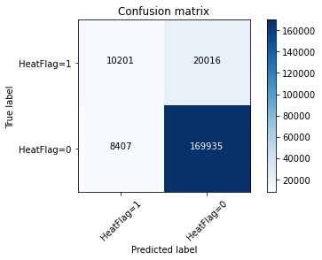

```python
# Compute confusion matrix
cnf_matrix = confusion_matrix(y_test['heat_flag'], yhat2, labels=[1,0])
np.set_printoptions(precision=2)


# Plot non-normalized confusion matrix
plt.figure()
plot_confusion_matrix(cnf_matrix, classes=['HeatFlag=1','HeatFlag=0'],normalize= False,  title='Confusion matrix')
```

## Now, we are using our reduced feature list to build a model around Target 2 (# of complaints)

```python
from sklearn.ensemble import RandomForestRegressor

regr = RandomForestRegressor()
regr.fit(X_train, y_train['heat_complaint_count'])
```

```
RandomForestRegressor()
```

```python
yhat_test = regr.predict(X_test)
yhat_train = regr.predict(X_train)
```

```python
from sklearn.metrics import mean_absolute_error, mean_squared_error

print('Mean Absolute Error - Test: %.3f' % mean_absolute_error(y_test['heat_complaint_count'], yhat_test))
print('Mean Absolute Error - Train: %.3f' % mean_absolute_error(y_train['heat_complaint_count'], yhat_train))

print("")

print('Mean Squared Error - Test: %.3f' % mean_squared_error(y_test['heat_complaint_count'], yhat_test))
print('Mean Squared Error - Train: %.3f' % mean_squared_error(y_train['heat_complaint_count'], yhat_train))

print("")

from sklearn.metrics import r2_score
print("R2-score - Test: %.2f" % r2_score(y_test['heat_complaint_count'], yhat_test))
print("R2-score - Train: %.2f" % r2_score(y_train['heat_complaint_count'], yhat_train))
```

```
Mean Absolute Error - Test: 3.001
Mean Absolute Error - Train: 1.160

Mean Squared Error - Test: 444.678
Mean Squared Error - Train: 70.216

R2-score - Test: 0.09
R2-score - Train: 0.87
```

##### I guess that didn't work very well

## I want to try something else

```python
from sklearn import linear_model

LR = linear_model.LinearRegression()
LR.fit(X_filter,y['heat_complaint_count'])
```

```
LinearRegression()
```

```python
# Get yHat prediction by testing the model
yhat_= LR.predict(X_train)

# get independent input
x_train_np = np.asanyarray(X_train)

# Get yActual
y_train_np = np.asanyarray(y_train['heat_complaint_count'])
```

```python
#use yHat and y to calculate the MSE
print("Residual sum of squares: %.2f" % np.mean((yhat_ - y_train_np) ** 2))

# Using the model, determine the R-squared between X and Y actual
print('Variance score: %.2f' % LR.score(x_train_np, y_train_np))
```

```
Residual sum of squares: 538.72
Variance score: 0.03
```

```python
del regr
del yhat
del yhat_test
del yhat_train

del X_filter
del ls_best_features

del c
del X_train
del X_test
del y_train
del y_test

del clf
del pipe
del Input

del df_pluto

del LR
```

## 2c. Feature Importance Function from XGBoost Algorithm

# !pip install xgboost

```python
# split data into train and test sets

feature_labels = list(X.columns)                                                          # List of feature labels for model
X = StandardScaler().fit(X).transform(X) # Standardize

seed = 7
test_size = 0.33
X_train, X_test, y_train, y_test = train_test_split(X, y, test_size=test_size, random_state=seed)
```

**By default, the predictions made by XGBoost are probabilities.**

- Because this is a binary classification problem, each prediction is the probability of the input pattern belonging to the first class.
- We can easily convert them to binary class values by rounding them to 0 or 1

[Click here for the example](https://machinelearningmastery.com/develop-first-xgboost-model-python-scikit-learn/)

```python
from xgboost import XGBClassifier
model = XGBClassifier()
model.fit(X_train, y_train['heat_flag'])
```

```
XGBClassifier()
```

```python
# make predictions for test data
y_pred = model.predict(X_test)
predictions = [round(value) for value in y_pred]

# evaluate predictions for training data
accuracy = accuracy_score(y_test['heat_flag'], predictions)
print("Accuracy on Test Set: %.2f%%" % (accuracy * 100.0))
```

```
Accuracy on Test Set: 87.80%
```

```python
# make predictions for training data
y_pred = model.predict(X_train)
predictions = [round(value) for value in y_pred]

# evaluate predictions for training data
accuracy = accuracy_score(y_train['heat_flag'], predictions)
print("Accuracy on Training Set: %.2f%%" % (accuracy * 100.0))
```

```
Accuracy on Training Set: 87.90%
```

## Evaluate XGBosst Classifer Model before we look at the most importance features as determined by the model object

```python
# feature labels
importances = model.feature_importances_

# Print the name and gini importance of each feature
for feature in zip(feature_labels, model.feature_importances_):
    print(feature)
```

```
('Lot', 0.029879939)
('ZipCode', 0.033584565)
('LotArea', 0.014207742)
('BldgArea', 0.020300483)
('ResArea', 0.3118522)
('OfficeArea', 0.0)
('RetailArea', 0.03677197)
('NumBldgs', 0.012402585)
('NumFloors', 0.03806437)
('LotDepth', 0.01243464)
('BldgDepth', 0.12694137)
('YearBuilt', 0.037449613)
('YearAlter1', 0.009483306)
('BuiltFAR', 0.19587375)
('ResidFAR', 0.061179005)
('CommFAR', 0.010462998)
('FacilFAR', 0.049111463)
('age', 0.0)
```

```python
list_of_tuples = list(zip(feature_labels, model.feature_importances_))              # step 1: get the list of tuples from two lists and merge them by using zip().

df1 = pd.DataFrame(list_of_tuples, columns = ['feature_labels', 'importance'])      # Converting lists of tuples into pandas Dataframe.

df1.sort_values(by=['importance'], ascending=False, inplace=True)                   # Sort dataframe
df1.reset_index(inplace=True, drop=True)                                            # Reset dataframe index
df1.head(7)
```

|  | feature_labels | importance |
| --- | --- | --- |
| 0 | ResArea | 0.311852 |
| 1 | BuiltFAR | 0.195874 |
| 2 | BldgDepth | 0.126941 |
| 3 | ResidFAR | 0.061179 |
| 4 | FacilFAR | 0.049111 |
| 5 | NumFloors | 0.038064 |
| 6 | YearBuilt | 0.037450 |

```
Mean: 0.0556
```

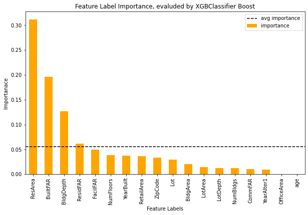

```python
mean_importance = df1['importance'].mean()                                          # Get Mean Importance Value
print('Mean: %.4f' % mean_importance)                                               # print Importance Mean value

df1.plot(kind='bar', figsize=(10, 6), color='orange')                               # step 2: plot data the dataframe

x_values = list(range(len(df1['feature_labels'].values)))                           # list of x locations for plotting [0,1,2,3,...,15,16,17]
plt.xticks(x_values, list(df1['feature_labels'].values))                            # Tick labels for x axis

plt.xlabel('Feature Labels')                                                        # add to x-label to the plot
plt.ylabel('Importanace')                                                           # add y-label to the plot
plt.title('Feature Label Importance, evaluded by XGBClassifier Boost')              # add title to the plot
plt.axhline(mean_importance,linestyle='--',color='black', label='avg importance')   # Plot horizontal mean line

plt.legend()
plt.show()
```

## This time only 4 features are above the average